# PW4GroupeIOS1.7 | Maxime BOURGEOIS | Victor CANAL | Thibault BUART | Jacques BUDIN | Alexandre BLANCHET

1. First, let’s do the pre-processing steps you were asked to do during the last session and fit a logistic regression model.

```r
dataset <- read.csv('http://www.mghassany.com/MLcourse/datasets/Social_Network_Ads.csv')


str(dataset)
```

```
## 'data.frame':    400 obs. of  5 variables:
##  $ User.ID        : int  15624510 15810944 15668575 15603246 15804002 15728773 15598044 15694829 15600575 15727311 ...
##  $ Gender         : Factor w/ 2 levels "Female","Male": 2 2 1 1 2 2 1 1 2 1 ...
##  $ Age            : num  19 35 26 27 19 27 27 32 25 35 ...
##  $ EstimatedSalary: num  19000 20000 43000 57000 76000 58000 84000 150000 33000 65000 ...
##  $ Purchased      : int  0 0 0 0 0 0 0 1 0 0 ...
```

```r
summary(dataset)
```

```
##     User.ID            Gender         Age        EstimatedSalary
##  Min.   :15566689   Female:204   Min.   :18.00   Min.   : 15000
##  1st Qu.:15626764   Male  :196   1st Qu.:29.75   1st Qu.: 43000
##  Median :15694342                Median :37.00   Median : 70000
##  Mean   :15691540                Mean   :37.66   Mean   : 69743
##  3rd Qu.:15750363                3rd Qu.:46.00   3rd Qu.: 88000
##  Max.   :15815236                Max.   :60.00   Max.   :150000
##    Purchased
##  Min.   :0.0000
##  1st Qu.:0.0000
##  Median :0.0000
##  Mean   :0.3575
##  3rd Qu.:1.0000
##  Max.   :1.0000
```

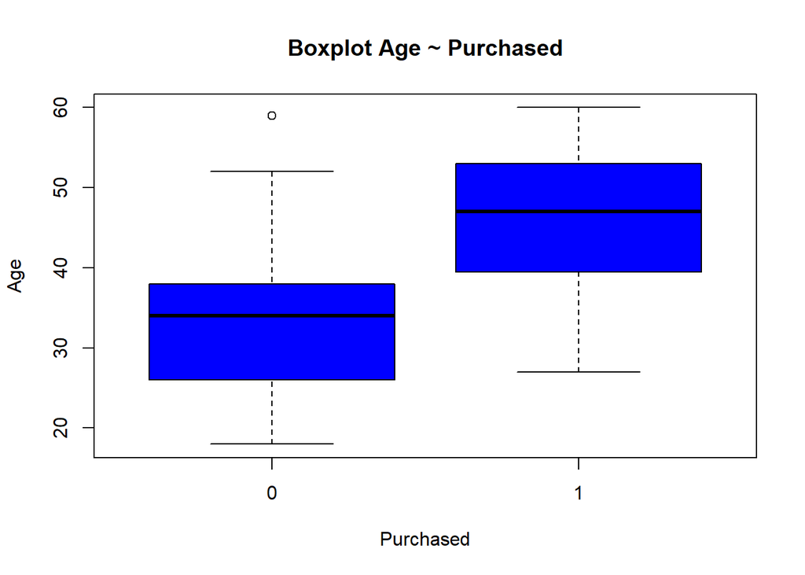

```r
boxplot(Age ~ Purchased, data=dataset, col = "blue", main="Boxplot Age ~ Purchased")
```

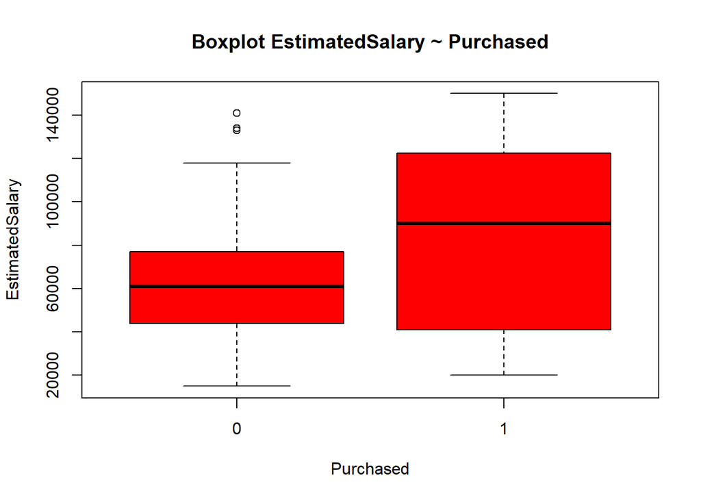

```r
boxplot(EstimatedSalary ~ Purchased, data=dataset,col = "red",
 main="Boxplot EstimatedSalary ~ Purchased")
```

```r
aov(EstimatedSalary ~Purchased, data=dataset)
```

```
## Call:
##    aov(formula = EstimatedSalary ~ Purchased, data = dataset)
##
## Terms:
##                    Purchased    Residuals
## Sum of Squares   60816378455 403062099045
## Deg. of Freedom            1          398
##
## Residual standard error: 31823.24
## Estimated effects may be unbalanced
```

```r
summary(aov(EstimatedSalary ~Purchased, data=dataset))
```

```
##              Df    Sum Sq   Mean Sq F value   Pr(>F)
## Purchased     1 6.082e+10 6.082e+10   60.05 7.77e-14 ***
## Residuals   398 4.031e+11 1.013e+09
## ---
## Signif. codes:  0 '***' 0.001 '**' 0.01 '*' 0.05 '.' 0.1 ' ' 1
```

```r
summary(aov(Age ~Purchased, data=dataset))
```

```
##              Df Sum Sq Mean Sq F value Pr(>F)
## Purchased     1  16988   16988   251.7 <2e-16 ***
## Residuals   398  26858      67
## ---
## Signif. codes:  0 '***' 0.001 '**' 0.01 '*' 0.05 '.' 0.1 ' ' 1
```

```r
table(dataset$Gender,dataset$Purchased)
```

```
##
##            0   1
##   Female 127  77
##   Male   130  66
```

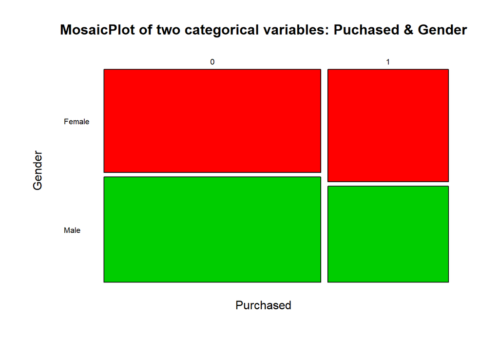

```r
mosaicplot(~ Purchased + Gender, data=dataset,
  main = "MosaicPlot of two categorical variables: Puchased & Gender",
  color = 2:3, las = 1)
```

```r
chisq.test(dataset$Purchased, dataset$Gender)
```

```
##
##  Pearson's Chi-squared test with Yates' continuity correction
##
## data:  dataset$Purchased and dataset$Gender
## X-squared = 0.55509, df = 1, p-value = 0.4562
```

```r
dataset = dataset[3:5]
str(dataset)
```

```
## 'data.frame':    400 obs. of  3 variables:
##  $ Age            : num  19 35 26 27 19 27 27 32 25 35 ...
##  $ EstimatedSalary: num  19000 20000 43000 57000 76000 58000 84000 150000 33000 65000 ...
##  $ Purchased      : int  0 0 0 0 0 0 0 1 0 0 ...
```

```r
library(caTools)
set.seed(700489)
split = sample.split(dataset$Purchased, SplitRatio = 0.75)
training_set = subset(dataset, split == TRUE)
test_set = subset(dataset, split == FALSE)


training_set[-3] <- scale(training_set[-3])
test_set[-3] <- scale(test_set[-3])



classifier.logreg <- glm(Purchased ~ Age + EstimatedSalary , family = binomial, data=training_set)
classifier.logreg
```

```
##
## Call:  glm(formula = Purchased ~ Age + EstimatedSalary, family = binomial,
##     data = training_set)
##
## Coefficients:
##     (Intercept)              Age  EstimatedSalary
##          -1.132            2.419            1.177
##
## Degrees of Freedom: 299 Total (i.e. Null);  297 Residual
## Null Deviance:       390.9
## Residual Deviance: 209.2     AIC: 215.2
```

```r
summary(classifier.logreg)
```

```
##
## Call:
## glm(formula = Purchased ~ Age + EstimatedSalary, family = binomial,
##     data = training_set)
##
## Deviance Residuals:
##     Min       1Q   Median       3Q      Max
## -2.9271  -0.5558  -0.1667   0.3937   2.3549
##
## Coefficients:
##                 Estimate Std. Error z value Pr(>|z|)
## (Intercept)      -1.1320     0.1935  -5.849 4.94e-09 ***
## Age               2.4186     0.3033   7.974 1.53e-15 ***
## EstimatedSalary   1.1773     0.2096   5.616 1.95e-08 ***
## ---
## Signif. codes:  0 '***' 0.001 '**' 0.01 '*' 0.05 '.' 0.1 ' ' 1
##
## (Dispersion parameter for binomial family taken to be 1)
##
##     Null deviance: 390.89  on 299  degrees of freedom
## Residual deviance: 209.24  on 297  degrees of freedom
## AIC: 215.24
##
## Number of Fisher Scoring iterations: 6
```

```r
pred.glm = predict(classifier.logreg, newdata = test_set[,-3], type="response")



pred.glm_0_1 = ifelse(pred.glm >= 0.5, 1,0)



head(pred.glm)
```

```
##           3           4           6           7          13          18
## 0.009661226 0.019279964 0.019931781 0.046817702 0.010696398 0.286150667
```

```r
head(pred.glm_0_1)
```

```
##  3  4  6  7 13 18
##  0  0  0  0  0  0
```

```r
cm = table(test_set[,3], pred.glm_0_1)
cm
```

```
##    pred.glm_0_1
##      0  1
##   0 59  5
##   1 10 26
```

```r
cm = table(pred.glm_0_1, test_set[,3])
cm
```

```
##
## pred.glm_0_1  0  1
##            0 59 10
##            1  5 26
```

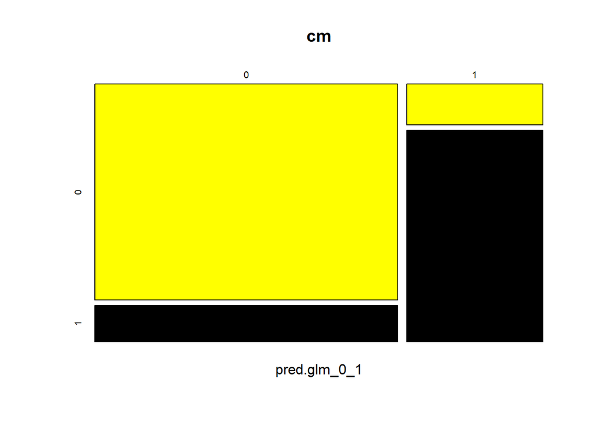

```r
mosaicplot(cm,col=sample(1:8,2))
```

```r
require(ROCR)
score <- prediction(pred.glm,test_set[,3])
performance(score,"auc")
```

```
## A performance instance
##   'Area under the ROC curve'
```

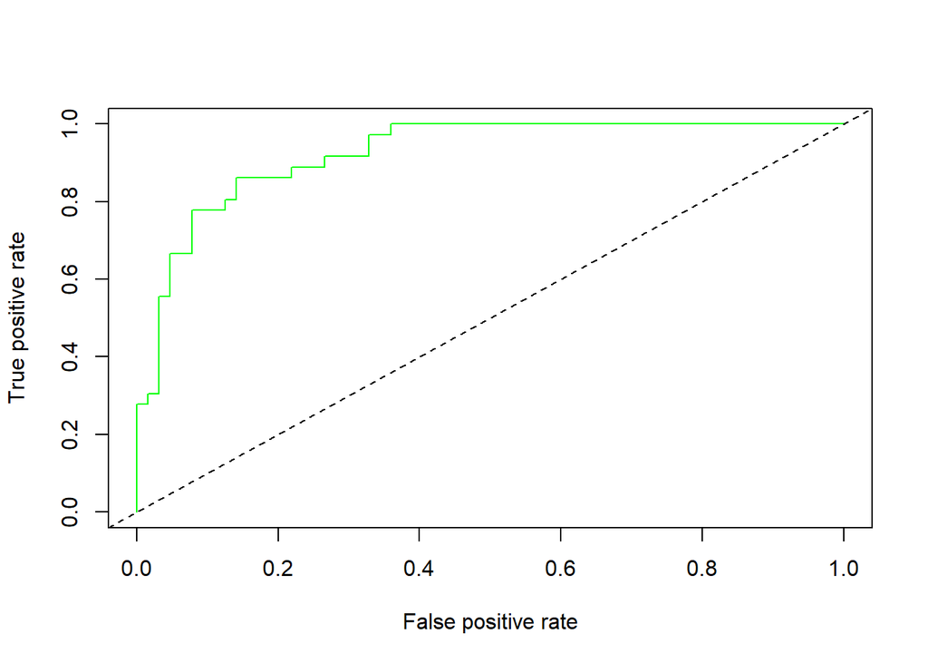

```r
plot(performance(score,"tpr","fpr"),col="green")
abline(0,1,lty=8)
```

2. Plot the decision boundary obtained with logistic regression. In order to do so, calculate the intercept and the slope of the line presenting the decision boundary, then plot EstimatedSalary in function of Age (from the test_set) and add the line using abline().
3. In order to verify that your line (decision boundary) is well plotted, color the points on the last Figure with respect to the predicted response.
4. Now make the same plot but color the points with respect to their real labels (the variable Purchased). From this figure, count the number of the false positive predictions and compare it to the value obtained in the confusion matrix.

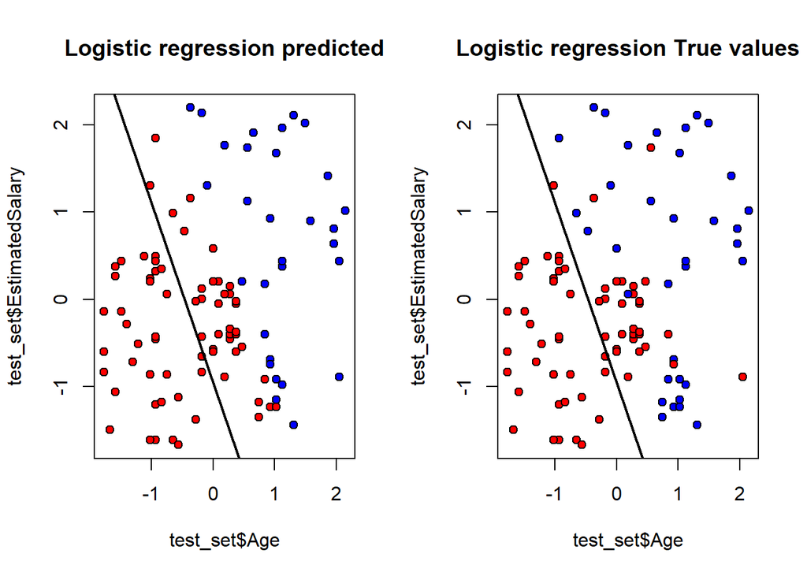

```r
lgtc_intercept <- classifier.logreg$coefficients['(Intercept)']
lgtc_Age <- classifier.logreg$coefficients['Age']
lgtc_EstimatedSalary <- classifier.logreg$coefficients['EstimatedSalary']


slope <- -(lgtc_Age/lgtc_EstimatedSalary)
intercept <- (lgtc_intercept/lgtc_EstimatedSalary)

layout(matrix(1:2, 1, 2))
plot(test_set$Age, test_set$EstimatedSalary,
     bg = ifelse(pred.glm_0_1 == 1, 'blue', 'red'),
     pch = 21,
     main = 'Logistic regression predicted')
abline(a = intercept, b = slope,
       lwd = 2)

plot(test_set$Age, test_set$EstimatedSalary,
     bg = ifelse(test_set$Purchased == 1, 'blue', 'red'),
     pch = 21,
     main = 'Logistic regression True values')
abline(a = intercept, b = slope,
       lwd = 2)
```

5. Fit a LDA model of Purchased in function of Age and EstimatedSalary. Name the model classifier.lda.

```r
library(MASS)
classifier.lda <- lda(Purchased~Age+EstimatedSalary, data=training_set)
```

6. Call classifier.lda and understand what does it compute.

```r
classifier.lda$prior
```

```
##         0         1
## 0.6433333 0.3566667
```

```r
classifier.lda$means
```

```
##          Age EstimatedSalary
## 0 -0.4655278      -0.2534548
## 1  0.8396904       0.4571661
```

7. On the test set, predict the probability of purchasing the product by the users using the model classifier.lda. Remark that when we predict using LDA, we obtain a list instead of a matrix, do str() for your predictions to see what do you get.

```r
predict_lda <- predict(classifier.lda, test_set, type = 'response')
predict_lda
```

```
## $class
##   [1] 0 0 0 0 0 0 1 1 0 0 0 0 0 0 0 0 0 0 0 0 0 0 0 0 0 0 0 1 0 0 1 0 0 0 0 0 0
##  [38] 0 0 0 0 1 0 0 0 0 0 0 0 0 0 0 0 1 0 1 1 1 0 1 0 0 1 1 1 0 1 0 1 1 0 0 1 0
##  [75] 0 0 1 0 1 1 0 1 1 1 0 1 0 0 1 0 0 0 1 0 0 1 1 1 0 1
## Levels: 0 1
##
## $posterior
##               0           1
## 3   0.986407348 0.013592652
## 4   0.975278127 0.024721873
## 6   0.974582470 0.025417530
## 7   0.948166834 0.051833166
## 13  0.986960130 0.013039870
## 18  0.681203107 0.318796893
## 22  0.421313407 0.578686593
```

[output cut: 196 more lines]

```r
str(predict_lda)
```

```
## List of 3
##  $ class    : Factor w/ 2 levels "0","1": 1 1 1 1 1 1 2 2 1 1 ...
##  $ posterior: num [1:100, 1:2] 0.986 0.975 0.975 0.948 0.987 ...
##   ..- attr(*, "dimnames")=List of 2
##   .. ..$ : chr [1:100] "3" "4" "6" "7" ...
##   .. ..$ : chr [1:2] "0" "1"
##  $ x        : num [1:100, 1] -1.66 -1.341 -1.326 -0.939 -1.682 ...
##   ..- attr(*, "dimnames")=List of 2
##   .. ..$ : chr [1:100] "3" "4" "6" "7" ...
##   .. ..$ : chr "LD1"
```

8. Compute the confusion matrix and compare the predictions results obtained by LDA to the ones obtained by logistic regression. What do you remark? (Hint: compare the accuracy)

```r
conf_matrix_lda <- table(predict_lda$class, test_set[,3])
conf_matrix_lda
```

```
##
##      0  1
##   0 59 11
##   1  5 25
```

```r
acc_lda <- (conf_matrix_lda[1,1] + conf_matrix_lda[2,2]) / (length(test_set$Purchased))
acc_lda
```

```
## [1] 0.84
```

9. Now let us plot the decision boundary obtained with LDA. You saw in the course that decision boundary for LDA represent the set of valuesx where deltak(x) = deltc(x)

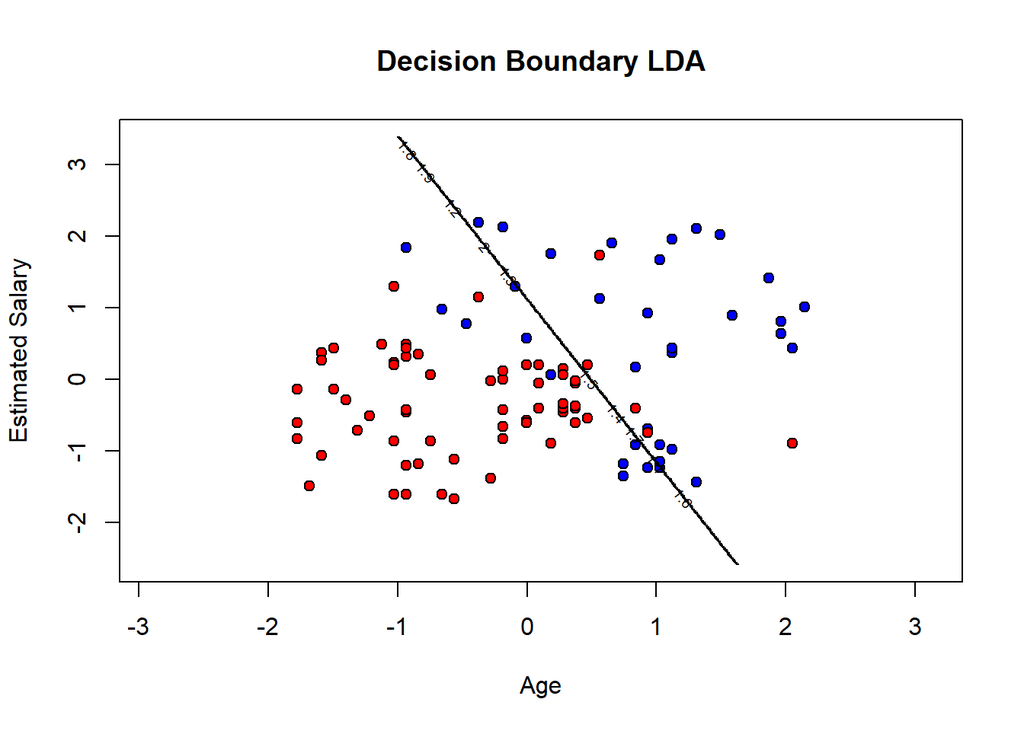

```r
X1 = seq(min(training_set[, 1]) - 1, max(training_set[, 1]) + 1, by = 0.01)
X2 = seq(min(training_set[, 2]) - 1, max(training_set[, 2]) + 1, by = 0.01)
grid_set = expand.grid(X1, X2)


colnames(grid_set) = c('Age', 'EstimatedSalary')

plot(test_set[, 1:2],
     main = 'Decision Boundary LDA',
     xlab = 'Age', ylab = 'Estimated Salary',
     xlim = range(X1), ylim = range(X2))


points(test_set[1:2], pch = 21, bg = ifelse(test_set[, 3] == 1, 'blue', 'red'))

pred_grid = predict(classifier.lda, newdata = grid_set)$class


contour(X1, X2, matrix(as.numeric(pred_grid), length(X1), length(X2)), add = TRUE)
```

10.1 Subset the training set into two sets: class0 where Purchased = 0 and class1 where Purchased = 1.

```r
class0 = training_set[training_set$Purchased==0,]
class1 = training_set[training_set$Purchased==1,]
```

10.2 Compute π0 and π1.

```r
n0 = nrow(class0)
n1 = nrow(class1)



pi0 = n0/nrow(training_set)
pi0
```

```
## [1] 0.6433333
```

```r
pi1 = n1/nrow(training_set)
pi1
```

```
## [1] 0.3566667
```

10.3 Compute μ0 and μ1.

```r
mu0 = c(mean(class0$Age), mean(class0$EstimatedSalary))
mu1 = c(mean(class1$Age), mean(class1$EstimatedSalary))
```

10.4 Compute Σ.

```r
matrixsum = ((n0 - 1)*cov(class0) + (n1 - 1)*cov(class1)) / (n0 + n1 - 2)
matrixsum
```

```
##                         Age EstimatedSalary Purchased
## Age              0.60983298     -0.07327503         0
## EstimatedSalary -0.07327503      0.88670712         0
## Purchased        0.00000000      0.00000000         0
```

11. Fit a QDA model of Purchased in function of Age and EstimatedSalary. Name the model classifier.qda.

```r
classifier.qda <- qda(Purchased~., data = training_set)
```

```r
pred.qda <- predict(classifier.qda, test_set, type = 'response')
pred.qda
```

```
## $class
##   [1] 0 0 0 0 0 1 1 1 1 1 0 0 0 0 0 0 0 0 0 0 0 0 0 0 0 0 0 1 0 0 0 0 0 0 0 0 0
##  [38] 0 0 0 0 1 0 0 0 0 0 0 0 0 0 0 0 1 0 1 1 1 0 1 0 0 1 1 1 0 1 0 1 1 0 0 1 0
##  [75] 0 0 1 0 1 1 0 1 1 1 0 1 1 1 1 0 0 1 1 0 0 1 1 1 1 1
## Levels: 0 1
##
## $posterior
##               0            1
## 3   0.995940017 0.0040599835
## 4   0.991618826 0.0083811738
## 6   0.991283692 0.0087163078
## 7   0.965791324 0.0342086757
## 13  0.988063759 0.0119362412
## 18  0.340267199 0.6597328015
## 22  0.340604683 0.6593953173
```

[output cut: 93 more lines]

```r
str(pred.qda)
```

```
## List of 2
##  $ class    : Factor w/ 2 levels "0","1": 1 1 1 1 1 2 2 2 2 2 ...
##  $ posterior: num [1:100, 1:2] 0.996 0.992 0.991 0.966 0.988 ...
##   ..- attr(*, "dimnames")=List of 2
##   .. ..$ : chr [1:100] "3" "4" "6" "7" ...
##   .. ..$ : chr [1:2] "0" "1"
```

13. Plot the decision boundary obtained with QDA. Color the points with the real labels

[figure not shown]

```r
X1 = seq(min(training_set[, 1]) - 1, max(training_set[, 1]) + 1, by = 0.01)
X2 = seq(min(training_set[, 2]) - 1, max(training_set[, 2]) + 1, by = 0.01)

colnames(grid_set) = c('Age', 'EstimatedSalary')

plot(test_set[, -3],
    main = 'Decision Boundary with the LDA',
    xlab = 'Age', ylab='Estimated Salary',
    xlim = range(X1), ylim = range(X2))

points(test_set, pch = 21, bg = ifelse(test_set[,3] == 1, 'blue','red'))

pred_grid = predict(classifier.qda, newdata = grid_set)$class

contour(X1,X2,matrix(as.numeric(pred_grid), length(X1), length(X2)), add = TRUE, lwd = 2)
```